# Coordinated Reference Systems with sf

Workshop: IDS Tools for Data Science - Exercises

Juan Brasdefer & Benedikt Korbach

November 21st 2022

Hello and welcome to our hands-on workshop session 👋,

We hope you enjoyed our presentation and gained a deeper understanding of spatial data and the `sf` package! Now, it’s your turn to measure (and map) the world!

In this exercise, you will

- further explore sf objects,
- learn to wrangle geographic data and
- create illustrative maps.

# Understanding CRS 🌎

## Exercise 1: Measuring the world

**After listening to the presentation, briefly talk to your neighbor… define the purpose of a CRS and discuss why it is important when dealing with spatial data.**

# Setup and Data 💻

First, we need to load all relevant packages and import the data we are going to use throughout the exercise. The data set contains the spatial data of all German districts as well as some population statistics.

```r
library(sf) # package for simple features
library(tidyverse)
library(units) # package to convert units
```

```r
german_districts <- st_read("./Data/german_districts_clean.shp")
```

# sf objects ℹ️

Let’s take a first look at the class of the `german_districts` object.

```r
class(german_districts)
```

```
## [1] "sf"         "data.frame"
```

The `german_districts` data set is saved as an `sf` object which at the same time is a data frame. That’s great! Thanks to this, we can effortlessly use tidyverse methods to wrangle our data.

Let’s make use of this fact in the first exercise!

## Exercise 2: Understanding sf objects

**Use the dplyr::select() function to select the ‘district’ column of the data frame and report the first five observations using the dplyr::head() and the print() function. What kind of information does the output contain? Does the output differ from what you expected?**

```r
german_districts %>%
  select(district) %>%
  head(5) %>%
  print
```

```
## Simple feature collection with 5 features and 1 field
## Geometry type: MULTIPOLYGON
## Dimension:     XY
## Bounding box:  xmin: 339789 ymin: 5332648 xmax: 756818 ymax: 5666646
## Projected CRS: ETRS89 / UTM zone 32N
##                    district                       geometry
## 1                 Ahrweiler MULTIPOLYGON (((373017.7 56...
## 2         Aichach-Friedberg MULTIPOLYGON (((649708.3 53...
## 3           Alb-Donau-Kreis MULTIPOLYGON (((569873.3 53...
## 4          Altenburger Land MULTIPOLYGON (((734500.1 56...
## 5 Altenkirchen (Westerwald) MULTIPOLYGON (((416304.5 56...
```

Further, we can note that although we subset by the `district` column, the geographic metadata of `german_districts` data frame and the `geometry` column is not lost. We can say that the `sf` show ‘sticky’ behavior.

To retrieve even more information about the CRS of our data, we can use the `st_crs()` function:

```r
st_crs(german_districts)
```

```
## Coordinate Reference System:
##   User input: ETRS89 / UTM zone 32N
##   wkt:
## PROJCRS["ETRS89 / UTM zone 32N",
##     BASEGEOGCRS["ETRS89",
##         ENSEMBLE["European Terrestrial Reference System 1989 ensemble",
##             MEMBER["European Terrestrial Reference Frame 1989"],
##             MEMBER["European Terrestrial Reference Frame 1990"],
##             MEMBER["European Terrestrial Reference Frame 1991"],
##             MEMBER["European Terrestrial Reference Frame 1992"],
##             MEMBER["European Terrestrial Reference Frame 1993"],
##             MEMBER["European Terrestrial Reference Frame 1994"],
##             MEMBER["European Terrestrial Reference Frame 1996"],
##             MEMBER["European Terrestrial Reference Frame 1997"],
##             MEMBER["European Terrestrial Reference Frame 2000"],
##             MEMBER["European Terrestrial Reference Frame 2005"],
##             MEMBER["European Terrestrial Reference Frame 2014"],
##             ELLIPSOID["GRS 1980",6378137,298.257222101,
##                 LENGTHUNIT["metre",1]],
##             ENSEMBLEACCURACY[0.1]],
##         PRIMEM["Greenwich",0,
##             ANGLEUNIT["degree",0.0174532925199433]],
##         ID["EPSG",4258]],
##     CONVERSION["UTM zone 32N",
##         METHOD["Transverse Mercator",
##             ID["EPSG",9807]],
##         PARAMETER["Latitude of natural origin",0,
##             ANGLEUNIT["degree",0.0174532925199433],
##             ID["EPSG",8801]],
##         PARAMETER["Longitude of natural origin",9,
##             ANGLEUNIT["degree",0.0174532925199433],
##             ID["EPSG",8802]],
##         PARAMETER["Scale factor at natural origin",0.9996,
##             SCALEUNIT["unity",1],
##             ID["EPSG",8805]],
##         PARAMETER["False easting",500000,
##             LENGTHUNIT["metre",1],
##             ID["EPSG",8806]],
##         PARAMETER["False northing",0,
##             LENGTHUNIT["metre",1],
##             ID["EPSG",8807]]],
##     CS[Cartesian,2],
##         AXIS["(E)",east,
##             ORDER[1],
##             LENGTHUNIT["metre",1]],
##         AXIS["(N)",north,
##             ORDER[2],
##             LENGTHUNIT["metre",1]],
##     USAGE[
##         SCOPE["Engineering survey, topographic mapping."],
##         AREA["Europe between 6°E and 12°E: Austria; Belgium; Denmark - onshore and offshore; Germany - onshore and offshore; Norway including - onshore and offshore; Spain - offshore."],
##         BBOX[38.76,6,84.33,12]],
##     ID["EPSG",25832]]
```

As we can see in the output, we receive all relevant information about the CRS in the form of Well-Known-Text (WKT), such as the projected CRS, the ellipsoid used to model the surface of the earth, or the area where the CRS should be used.

We can also filter out the relevant CRS information in the different formats discussed in the presentation (EPSG and Proj4):

```r
st_crs(german_districts)$srid
```

```
## [1] "EPSG:25832"
```

```r
st_crs(german_districts)$proj4string
```

```
## [1] "+proj=utm +zone=32 +ellps=GRS80 +towgs84=0,0,0,0,0,0,0 +units=m +no_defs"
```

# Changing the CRS 🔀

For some applications and areas, certain types of CRSs are more suitable than others. For example, as we discussed in the presentation, certain projections focus on preserving the area of geographical features such as countries, while others focus on retaining the shape or the direction. Further, some CRSs use a local instead of a geocentric datum that better fits the surface of a specific location on earth (remember: the datum specifies the positioning of the ellipsoid with respect to the actual surface of the earth). To look up different CRSs, you find more information on [Coordinate Systems Worldwide](https://epsg.io/).

We can change the CRS of an `sf` object by applying the `st_set_crs()` function:

```r
german_districts_equidistant <- german_districts %>%
  st_set_crs(4087)

st_crs(german_districts_equidistant)
```

```
## Coordinate Reference System:
##   User input: EPSG:4087
##   wkt:
## PROJCRS["WGS 84 / World Equidistant Cylindrical",
##     BASEGEOGCRS["WGS 84",
##         ENSEMBLE["World Geodetic System 1984 ensemble",
##             MEMBER["World Geodetic System 1984 (Transit)"],
##             MEMBER["World Geodetic System 1984 (G730)"],
##             MEMBER["World Geodetic System 1984 (G873)"],
##             MEMBER["World Geodetic System 1984 (G1150)"],
##             MEMBER["World Geodetic System 1984 (G1674)"],
##             MEMBER["World Geodetic System 1984 (G1762)"],
##             MEMBER["World Geodetic System 1984 (G2139)"],
##             ELLIPSOID["WGS 84",6378137,298.257223563,
##                 LENGTHUNIT["metre",1]],
##             ENSEMBLEACCURACY[2.0]],
##         PRIMEM["Greenwich",0,
##             ANGLEUNIT["degree",0.0174532925199433]],
##         ID["EPSG",4326]],
##     CONVERSION["World Equidistant Cylindrical",
##         METHOD["Equidistant Cylindrical",
##             ID["EPSG",1028]],
##         PARAMETER["Latitude of 1st standard parallel",0,
##             ANGLEUNIT["degree",0.0174532925199433],
##             ID["EPSG",8823]],
##         PARAMETER["Longitude of natural origin",0,
##             ANGLEUNIT["degree",0.0174532925199433],
##             ID["EPSG",8802]],
##         PARAMETER["False easting",0,
##             LENGTHUNIT["metre",1],
##             ID["EPSG",8806]],
##         PARAMETER["False northing",0,
##             LENGTHUNIT["metre",1],
##             ID["EPSG",8807]]],
##     CS[Cartesian,2],
##         AXIS["easting (X)",east,
##             ORDER[1],
##             LENGTHUNIT["metre",1]],
##         AXIS["northing (Y)",north,
##             ORDER[2],
##             LENGTHUNIT["metre",1]],
##     USAGE[
##         SCOPE["Graticule coordinates expressed in simple Cartesian form."],
##         AREA["World."],
##         BBOX[-90,-180,90,180]],
##     ID["EPSG",4087]]
```

Here, we set the CRS to the WGS84 / World Equidistant Cylindrical standard that uses the WGS84 ellipsoid - one of the most common ellipsoids used to model the earth - and projects geographical features in a way that preserves distances.

Now, its your turn to try the same. 💪

## Exercise 3: Setting the CRS

**Use the st_set_crs() function to change the CRS of german_districts to WGS84/ Pseudo-Mercator (EPSG:3857) and store it as german_districts_mercator. By applying the st_crs() function, retrieve more information about the WGS84/ Pseudo-Mercator standard.**

```r
german_districts_mercator <- german_districts %>%
  st_set_crs(3857) # WGS84; commonly used by organizations that provide spatial data for the entire globe or many countries; for example used by Google Earth

st_crs(german_districts_mercator)
```

```
## Coordinate Reference System:
##   User input: EPSG:3857
##   wkt:
## PROJCRS["WGS 84 / Pseudo-Mercator",
##     BASEGEOGCRS["WGS 84",
##         ENSEMBLE["World Geodetic System 1984 ensemble",
##             MEMBER["World Geodetic System 1984 (Transit)"],
##             MEMBER["World Geodetic System 1984 (G730)"],
##             MEMBER["World Geodetic System 1984 (G873)"],
##             MEMBER["World Geodetic System 1984 (G1150)"],
##             MEMBER["World Geodetic System 1984 (G1674)"],
##             MEMBER["World Geodetic System 1984 (G1762)"],
##             MEMBER["World Geodetic System 1984 (G2139)"],
##             ELLIPSOID["WGS 84",6378137,298.257223563,
##                 LENGTHUNIT["metre",1]],
##             ENSEMBLEACCURACY[2.0]],
##         PRIMEM["Greenwich",0,
##             ANGLEUNIT["degree",0.0174532925199433]],
##         ID["EPSG",4326]],
##     CONVERSION["Popular Visualisation Pseudo-Mercator",
##         METHOD["Popular Visualisation Pseudo Mercator",
##             ID["EPSG",1024]],
##         PARAMETER["Latitude of natural origin",0,
##             ANGLEUNIT["degree",0.0174532925199433],
##             ID["EPSG",8801]],
##         PARAMETER["Longitude of natural origin",0,
##             ANGLEUNIT["degree",0.0174532925199433],
##             ID["EPSG",8802]],
##         PARAMETER["False easting",0,
##             LENGTHUNIT["metre",1],
##             ID["EPSG",8806]],
##         PARAMETER["False northing",0,
##             LENGTHUNIT["metre",1],
##             ID["EPSG",8807]]],
##     CS[Cartesian,2],
##         AXIS["easting (X)",east,
##             ORDER[1],
##             LENGTHUNIT["metre",1]],
##         AXIS["northing (Y)",north,
##             ORDER[2],
##             LENGTHUNIT["metre",1]],
##     USAGE[
##         SCOPE["Web mapping and visualisation."],
##         AREA["World between 85.06°S and 85.06°N."],
##         BBOX[-85.06,-180,85.06,180]],
##     ID["EPSG",3857]]
```

From the output, we can see that this CRS also uses the WGS 84 geographical reference system that is then mapped onto a two-dimensional cartesian plane as a Pseudo-Mercator projection.

Let’s plot two maps of Germany with the two different CRS specifications:

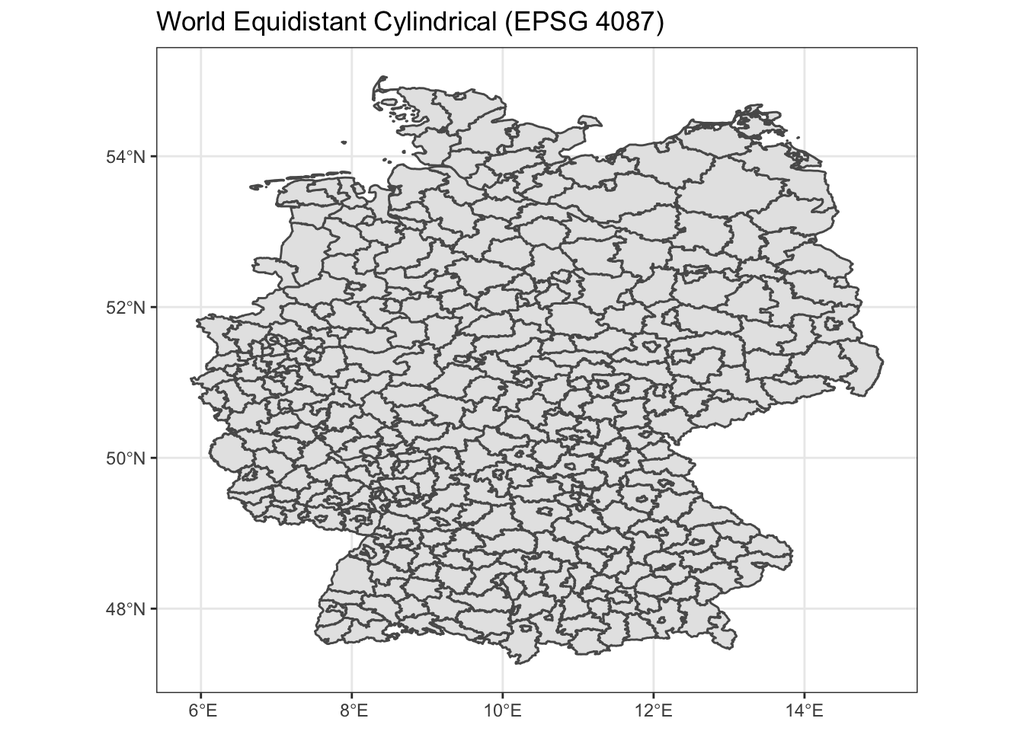

```r
german_districts %>%
  ggplot() +
  geom_sf() +
  coord_sf(crs = st_crs(4087)) +
  ggtitle("World Equidistant Cylindrical (EPSG 4087)") +
  theme_bw()
```

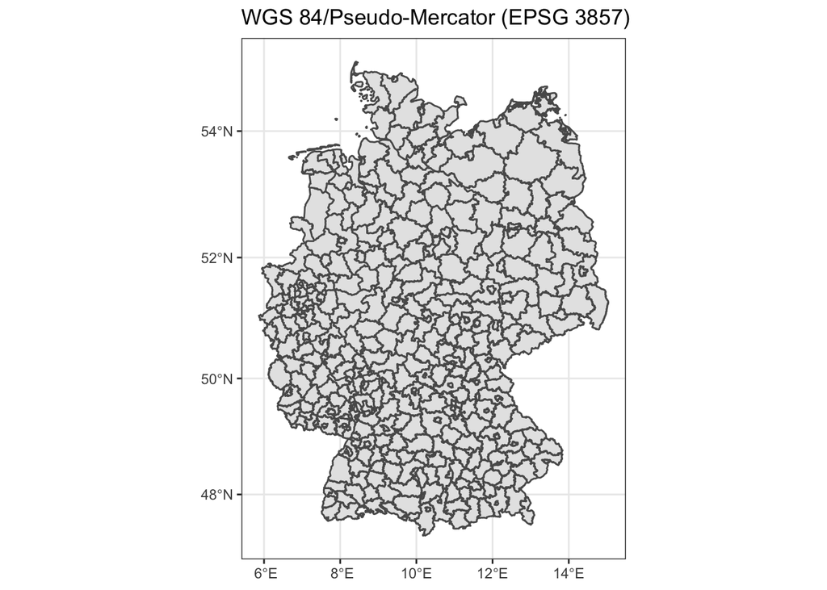

```r
german_districts %>%
  ggplot() +
  geom_sf() +
  coord_sf(crs = st_crs(3857)) +
  ggtitle("WGS 84/Pseudo-Mercator (EPSG 3857)") +
  theme_bw()
```

As we can see, the specification of the two CRSs results in quite different representations of Germany.

# Computations with sf 🧭

In this section, we want to show that you can also do calculations with spatial data by utilizing `sf` package methods.

Let’s use our spatial data to calculate the area of each German district.

## Exercise 4: Computing areas

**Calculate the areas of all German districts and store them in a new column within the data frame using the dplyr::mutate() function. Change the unit to square kilometers using the units::set_units() function of the units package. Report the area of Berlin.**

```r
german_districts <- german_districts %>%
  mutate(area = set_units(st_area(german_districts), km^2))
```

```r
german_districts %>%
  filter(district == "Berlin") %>%
  select(area)
```

|  | area | geometry |
| --- | --- | --- |
| 1 | 893.0486 [km^2] |  |

Berlin has an area of 893 square kilometers.

Similar to the calculation of area, there are other functions in the `sf` package that you can use to do computations with simple features such as `st_length()`or `st_distance()`.

As a second step, let’s calculate the population density for each district using the `dplyr` package.

```r
german_districts <- german_districts %>%
  mutate(density = as.double(pop/area))
```

```r
district_points <- cbind(german_districts, st_coordinates(st_centroid(german_districts$geometry)))

district_points <- district_points %>%
  arrange(desc(density)) %>%
  select(district, density) %>%
  head(5)

print(district_points)
```

```
## Simple feature collection with 5 features and 2 fields
## Geometry type: MULTIPOLYGON
## Dimension:     XY
## Bounding box:  xmin: 369882.2 ymin: 5326187 xmax: 823510.5 ymax: 5845512
## Projected CRS: ETRS89 / UTM zone 32N
##            district  density                       geometry
## 1           München 4656.466 MULTIPOLYGON (((689101.1 53...
## 2            Berlin 3941.589 MULTIPOLYGON (((802565.3 58...
## 3             Herne 3027.048 MULTIPOLYGON (((378685.1 57...
## 4         Stuttgart 2975.624 MULTIPOLYGON (((516514.1 54...
## 5 Frankfurt am Main 2953.483 MULTIPOLYGON (((479412.4 55...
```

Based on our calculation, Munich is the densest city in Germany with a population density of 4656 inhabitants per square kilometer.

Now, let’s use this information and exploit one of the most powerful techniques in geographic data handling: map-making!

# Creating illustrative maps 🗺️

An easy way to graph maps is the included `plot()` command that create a set of default maps corresponding to the attributes of our `sf` object. Let’s plot the first three attributes:

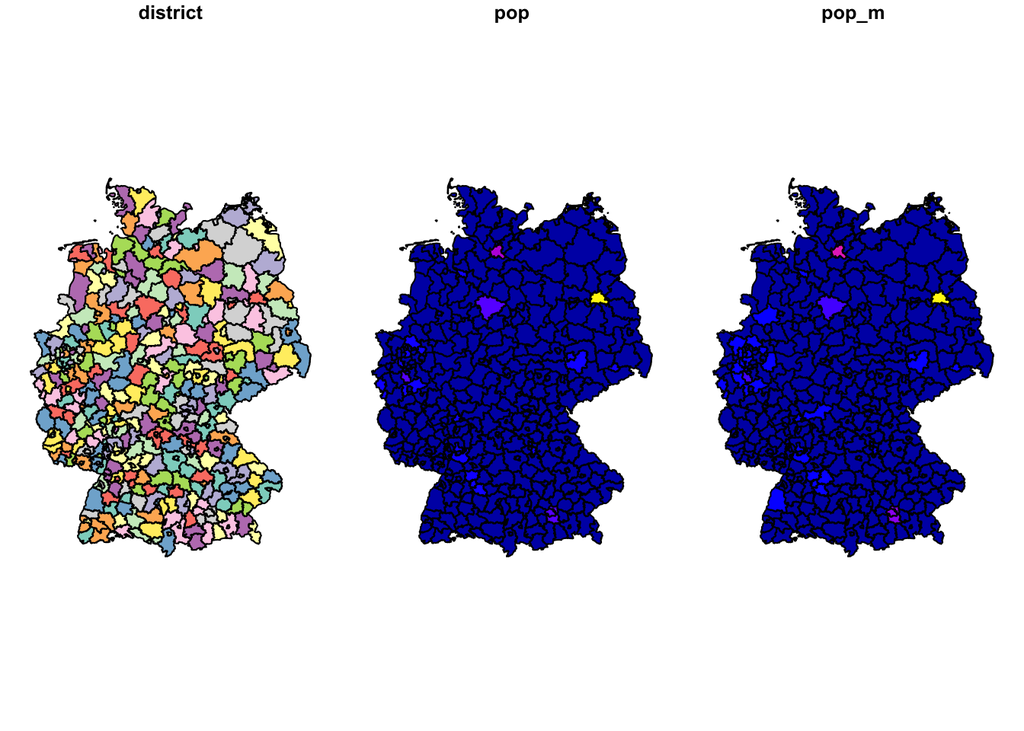

```r
plot(german_districts, max.plot = 3)
```

Since `german_districts` is stored as a data frame, we can also utilize the ggplot2 package to create maps.

## Exercise 5: Creating a map

**Create a map of the population density of all German districts using the ggplot package and the geom_sf() function.** Hint: To specify that you want to fill the districts according to the population density, set the “fill” attribute within the `aes()` command equal to the name of the population density column.

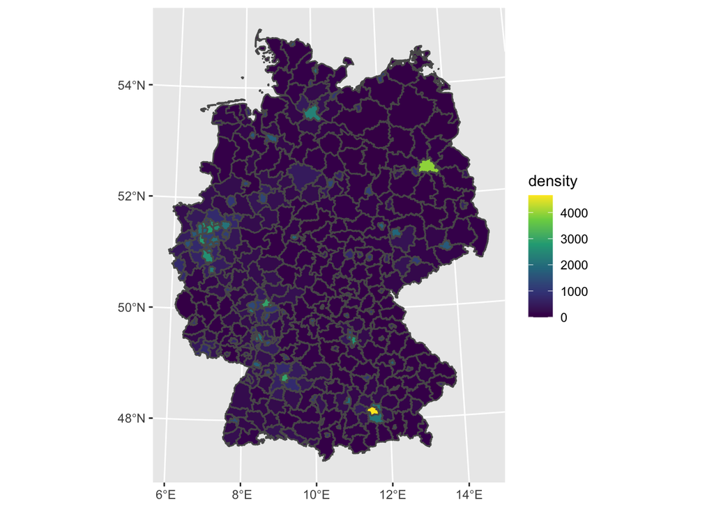

```r
german_districts %>%
  ggplot() +
  geom_sf(aes(fill = density)) +
  scale_fill_viridis_c()
```

We can clearly see the densely populated parts of Germany: The big German cities of Hamburg in the north, Berlin in the north-east and Munich in the south.

That’s it with the workshop. Thank you so much for participating!

We hope that you had a great learning experience. If you have further questions, feel free to contact us. Also, if you want to dive deeper into the topic, take a look at the sources below and the material referenced in our GitHub repo.

### Sources

This exercise makes use of the data compiled by the Statistics and Geospatial Data Analysis (SOGA) unit of the [*Freie Universität Berlin*](https://www.geo.fu-berlin.de/en/v/soga/Introduction-to-R/Spatial-Data/sf/index.html).

Further sources of inspiration used to create this material include:

*[*Simple Features in R*](https://cran.r-project.org/web/packages/sf/vignettes/sf1.html)

*[*Geocomputation with R*](https://geocompr.robinlovelace.net/spatial-class.html#geographic-coordinate-systems)